# Data Mining Homework1(Building_Permits.csv)

First, install some packages needed.

Import the data and have a brief look.

```r
b_p=read.csv("Building_Permits.csv")
b_p[1:10,]
```

|  | Permit.Number | Permit.Type | Permit.Type.Definition | Permit.Creation.Date | Block | Lot | Street.Number | Street.Number.Suffix | Street.Name | Street.Suffix | Unit | Unit.Suffix | Description | Current.Status | Current.Status.Date | Filed.Date | Issued.Date | Completed.Date | First.Construction.Document.Date | Structural.Notification | Number.of.Existing.Stories | Number.of.Proposed.Stories | Voluntary.Soft.Story.Retrofit | Fire.Only.Permit | Permit.Expiration.Date | Estimated.Cost | Revised.Cost | Existing.Use | Existing.Units | … |
| --- | --- | --- | --- | --- | --- | --- | --- | --- | --- | --- | --- | --- | --- | --- | --- | --- | --- | --- | --- | --- | --- | --- | --- | --- | --- | --- | --- | --- | --- | --- |
| 1 | 201505065519 | 4 | sign - erect | 05/06/2015 | 0326 | 023 | 140 |  | Ellis | St | NA |  | ground fl facade: to erect illuminated, electric, wall, single faced sign. n/a for maher ordinance 155-13. | expired | 12/21/2017 | 05/06/2015 | 11/09/2015 |  | 11/09/2015 |  | 6 | NA |  |  | 11/03/2016 | 4000 | 4000 | tourist hotel/motel | 143 | … |
| 2 | 201604195146 | 4 | sign - erect | 04/19/2016 | 0306 | 007 | 440 |  | Geary | St | 0 |  | remove (e) awning and associated signs. | issued | 08/03/2017 | 04/19/2016 | 08/03/2017 |  | 08/03/2017 |  | 7 | NA |  |  | 12/03/2017 | 1 | 500 | tourist hotel/motel | NA | … |
| 3 | 201605278609 | 3 | additions alterations or repairs | 05/27/2016 | 0595 | 203 | 1647 |  | Pacific | Av | NA |  | installation of separating wall | withdrawn | 09/26/2017 | 05/27/2016 |  |  |  |  | 6 | 6 |  |  |  | 20000 | NA | retail sales | 39 | … |
| 4 | 201611072166 | 8 | otc alterations permit | 11/07/2016 | 0156 | 011 | 1230 |  | Pacific | Av | 0 |  | repair dryrot & stucco at front of bldg. | complete | 07/24/2017 | 11/07/2016 | 07/18/2017 | 07/24/2017 | 07/18/2017 |  | 2 | 2 |  |  | 07/13/2018 | 2000 | 2000 | 1 family dwelling | 1 | … |
| 5 | 201611283529 | 6 | demolitions | 11/28/2016 | 0342 | 001 | 950 |  | Market | St | NA |  | demolish retail/office/commercial 3-story building | issued | 12/01/2017 | 11/28/2016 | 12/01/2017 |  | 11/20/2017 |  | 3 | NA |  |  | 12/01/2018 | 100000 | 100000 | retail sales | NA | … |
| 6 | 201706149344 | 8 | otc alterations permit | 06/14/2017 | 4105 | 009 | 800 |  | Indiana | St | NA |  | evac maps | issued | 07/06/2017 | 06/14/2017 | 07/06/2017 |  | 07/06/2017 |  | 5 | 5 |  | Y | 07/01/2018 | 4000 | 4000 | apartments | 326 | … |
| 7 | 201706300814 | 8 | otc alterations permit | 06/30/2017 | 1739 | 020 | 1291 |  | 11th | Av | 0 |  | re-roofing | complete | 07/12/2017 | 06/30/2017 | 06/30/2017 | 07/12/2017 | 06/30/2017 |  | 3 | 3 |  |  | 06/25/2018 | 12000 | 12000 | apartments | 5 | … |
| 8 | M803667 | 8 | otc alterations permit | 06/30/2017 | 4789 | 014 | 1465 |  | Revere | Av | NA |  | streetspace | issued | 06/30/2017 | 06/30/2017 | 06/30/2017 |  | 06/30/2017 |  | NA | NA |  |  |  | NA | 0 |  | NA | … |
| 9 | M804227 | 8 | otc alterations permit | 07/05/2017 | 1212 | 054 | 2094 |  | Fell | St | NA |  | street space permit | issued | 07/05/2017 | 07/05/2017 | 07/05/2017 |  | 07/05/2017 |  | NA | NA |  |  |  | NA | 1 |  | NA | … |
| 10 | M804767 | 8 | otc alterations permit | 07/06/2017 | 1259 | 016 | 89 |  | Alpine | Tr | NA |  | street space | issued | 07/06/2017 | 07/06/2017 | 07/06/2017 |  | 07/06/2017 |  | NA | NA |  |  |  | NA | 0 |  | NA | … |

Now, we know the structure of the data.

Nominal attributes: Permit.Type, Street.Number, Street.Name, Street.Suffix, Current.Status, Existing.Use, Proposed.Use, Existing.Construction.Type, Proposed.Construction.Type, Zipcode, Neighborhood…Analysis.Boundaries

Then the summary can be done.

Divide the data set into two data.frame: p_nominal and p_numeric

```r
b_p_nominal<-select(b_p,Permit.Type, Street.Number, Street.Name, Street.Suffix, Current.Status, Existing.Use, Proposed.Use, Existing.Construction.Type, Proposed.Construction.Type, Zipcode, Plansets, Supervisor.District)


b_p_numeric<-select(b_p,Unit, Number.of.Existing.Stories, Number.of.Proposed.Stories, Estimated.Cost, Revised.Cost, Existing.Units, Proposed.Units)
```

Begin the summary.

```r
summary(b_p_numeric)
```

```
##       Unit         Number.of.Existing.Stories Number.of.Proposed.Stories
##  Min.   :   0.00   Min.   : 0.00              Min.   : 0.00
##  1st Qu.:   0.00   1st Qu.: 2.00              1st Qu.: 2.00
##  Median :   0.00   Median : 3.00              Median : 3.00
##  Mean   :  78.52   Mean   : 5.71              Mean   : 5.75
##  3rd Qu.:   1.00   3rd Qu.: 4.00              3rd Qu.: 4.00
##  Max.   :6004.00   Max.   :78.00              Max.   :78.00
##  NA's   :169421    NA's   :42784              NA's   :42868
##  Estimated.Cost      Revised.Cost       Existing.Units
##  Min.   :1.00e+00   Min.   :        0   Min.   :   0.00
##  1st Qu.:3.30e+03   1st Qu.:        1   1st Qu.:   1.00
##  Median :1.10e+04   Median :     7000   Median :   1.00
##  Mean   :1.69e+05   Mean   :   132856   Mean   :  15.67
##  3rd Qu.:3.50e+04   3rd Qu.:    28708   3rd Qu.:   4.00
##  Max.   :5.38e+08   Max.   :780500000   Max.   :1907.00
##  NA's   :38066      NA's   :6066        NA's   :51538
##  Proposed.Units
##  Min.   :   0.00
##  1st Qu.:   1.00
##  Median :   2.00
##  Mean   :  16.51
##  3rd Qu.:   4.00
##  Max.   :1911.00
##  NA's   :50911
```

```r
b_p_nominal[["Permit.Type"]]<-as.factor(b_p_nominal[["Permit.Type"]])
b_p_nominal[["Street.Number"]]<-as.factor(b_p_nominal[["Street.Number"]])
b_p_nominal[["Existing.Construction.Type"]]<-as.factor(b_p_nominal[["Existing.Construction.Type"]])
b_p_nominal[["Proposed.Construction.Type"]]<-as.factor(b_p_nominal[["Proposed.Construction.Type"]])
b_p_nominal[["Zipcode"]]<-as.factor(b_p_nominal[["Zipcode"]])
b_p_nominal[["Plansets"]]<-as.factor(b_p_nominal[["Plansets"]])
b_p_nominal[["Supervisor.District"]]<-as.factor(b_p_nominal[["Supervisor.District"]])
summary(b_p_nominal)
```

```
##   Permit.Type     Street.Number        Street.Name     Street.Suffix
##  8      :178844   1      :  2394   Market    :  5443   St     :138358
##  3      : 14663   101    :  1153   California:  4587   Av     : 43219
##  4      :  2892   100    :  1143   Mission   :  4209   Bl     :  3555
##  2      :   950   50     :  1103   Montgomery:  2403   Wy     :  3540
##  6      :   600   201    :  1026   Geary     :  1966   Dr     :  3267
##  7      :   511   555    :   994   20th      :  1859          :  2768
##  (Other):   440   (Other):191087   (Other)   :178433   (Other):  4193
##    Current.Status             Existing.Use              Proposed.Use
##  complete :97077   1 family dwelling:46766   1 family dwelling:46346
##  issued   :83559                    :41114   apartments       :43032
##  filed    :12043   apartments       :40798                    :42439
##  withdrawn: 1754   office           :24616   office           :23962
##  cancelled: 1536   2 family dwelling:20987   2 family dwelling:22061
##  expired  : 1370   retail sales     : 6910   retail sales     : 5079
##  (Other)  : 1561   (Other)          :17709   (Other)          :15981
##  Existing.Construction.Type Proposed.Construction.Type    Zipcode
##  1   : 28072                1   : 27841                94110  : 17837
##  2   :  4068                2   :  3778                94114  : 13404
##  3   :  9663                3   :  9360                94117  : 11780
##  4   :   381                4   :   377                94109  : 11348
##  5   :113350                5   :114382                94103  : 10986
##  NA's: 43366                NA's: 43162                (Other):131829
##                                                        NA's   :  1716
##     Plansets     Supervisor.District
##  2      :98088   3      :28649
##  0      :63244   8      :26760
##  3      :  250   2      :25483
##  4      :    3   6      :24797
##  1      :    2   5      :19045
##  (Other):    4   (Other):72449
##  NA's   :37309   NA's   : 1717
```

```r
library(plyr)
library(Hmisc)
plyr::count(b_p[["Permit.Type"]])
```

| x | freq |
| --- | --- |
| 1 | 349 |
| 2 | 950 |
| 3 | 14663 |
| 4 | 2892 |
| 5 | 91 |
| 6 | 600 |
| 7 | 511 |
| 8 | 178844 |

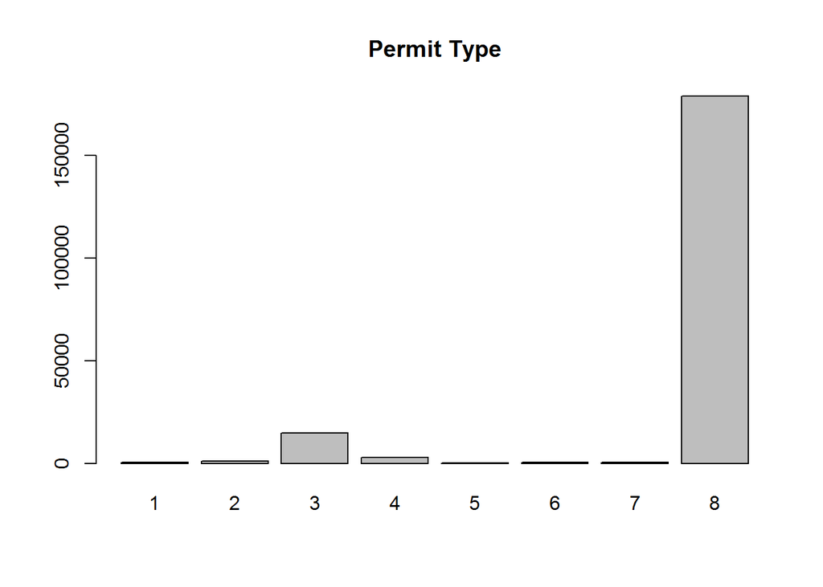

```r
b_p_permit_type_counts<-plyr::count(b_p[["Permit.Type"]])$freq
names(b_p_permit_type_counts)<-plyr::count(b_p[["Permit.Type"]])$x
barplot(b_p_permit_type_counts,main="Permit Type")
```

Visualization begins. Visualize Unit. From the QQ plot below, it is clearly the Unit does not fit the normal distribution.

```r
plyr::count(is.na(b_p[["Unit"]]))
```

| x | freq |
| --- | --- |
| FALSE | 29479 |
| TRUE | 169421 |

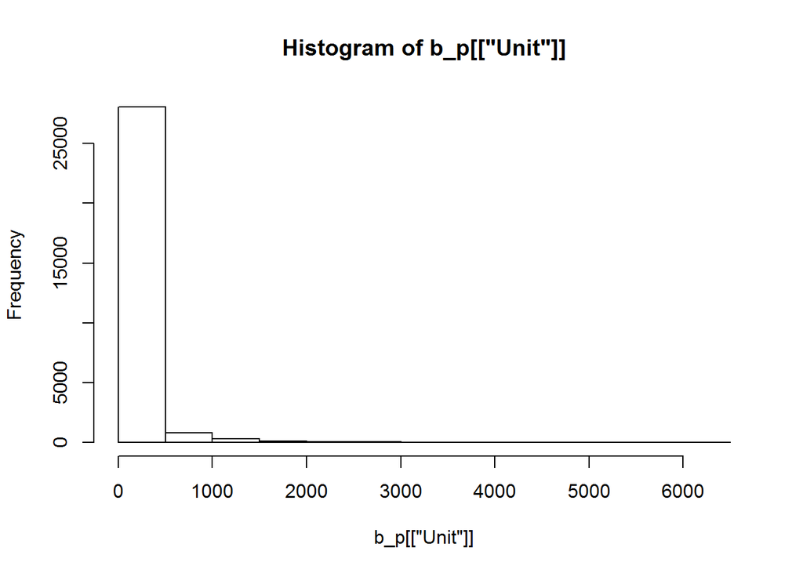

```r
hist(b_p[["Unit"]])
```

```r
boxplot(b_p[["Unit"]])
```

[output not shown]

```r
summary(b_p[["Unit"]])
```

```
##    Min. 1st Qu.  Median    Mean 3rd Qu.    Max.    NA's
##    0.00    0.00    0.00   78.52    1.00 6004.00  169421
```

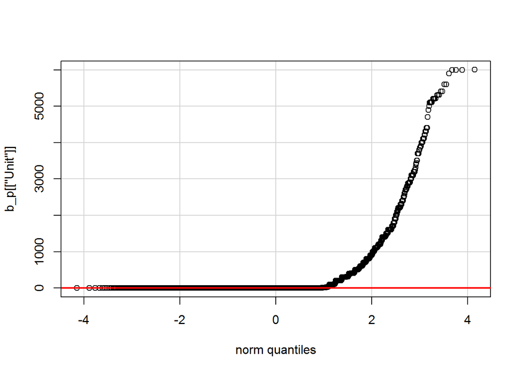

```r
qqPlot(b_p[["Unit"]])
```

```r
b_p_unit_innormal<-dplyr::filter(b_p,Unit==0 | Unit>759.5)
summary(b_p_unit_innormal[["Unit"]])
```

```
##    Min. 1st Qu.  Median    Mean 3rd Qu.    Max.
##    0.00    0.00    0.00   61.36    0.00 6004.00
```

Visualize “Number.of.Existing.Stories.

```r
summary(b_p[["Number.of.Existing.Stories"]])
```

```
##    Min. 1st Qu.  Median    Mean 3rd Qu.    Max.    NA's
##    0.00    2.00    3.00    5.71    4.00   78.00   42784
```

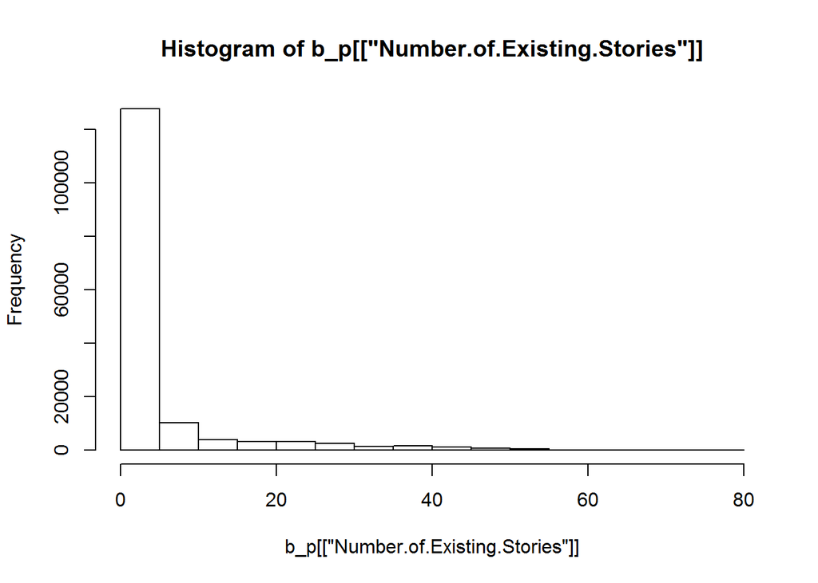

```r
hist(b_p[["Number.of.Existing.Stories"]])
```

```r
boxplot(b_p[["Number.of.Existing.Stories"]])
```

[output not shown]

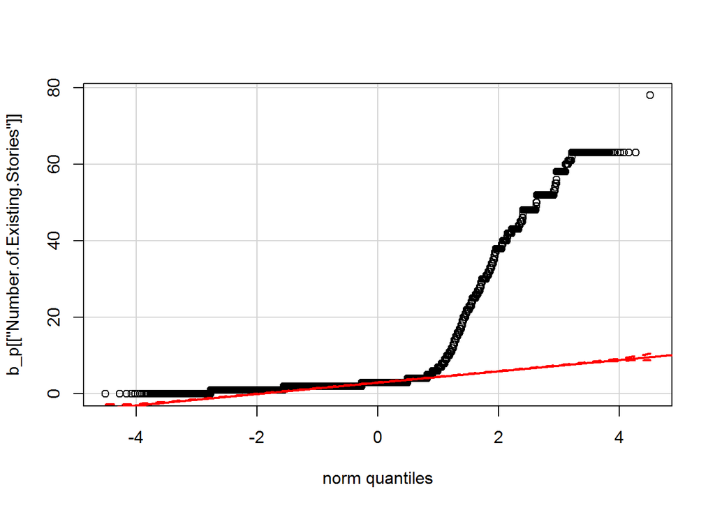

```r
qqPlot(b_p[["Number.of.Existing.Stories"]])
```

Visualize Number.of.Proposed.Stories.

```r
summary(b_p[["Number.of.Proposed.Stories"]])
```

```
##    Min. 1st Qu.  Median    Mean 3rd Qu.    Max.    NA's
##    0.00    2.00    3.00    5.75    4.00   78.00   42868
```

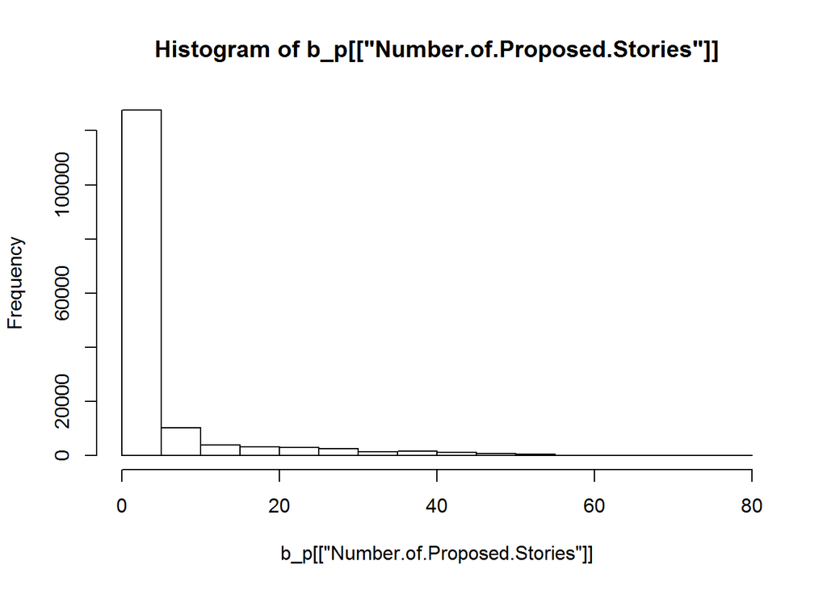

```r
hist(b_p[["Number.of.Proposed.Stories"]])
```

```r
boxplot(b_p[["Number.of.Proposed.Stories"]])
```

[output not shown]

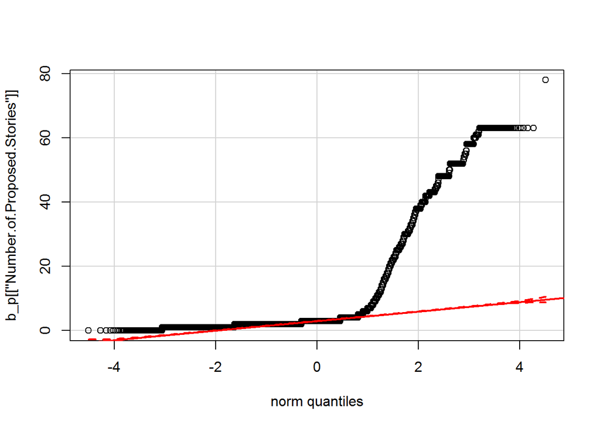

```r
qqPlot(b_p[["Number.of.Proposed.Stories"]])
```

Visualize Estimated.Cost.

```r
summary(b_p[["Estimated.Cost"]])
```

```
##     Min.  1st Qu.   Median     Mean  3rd Qu.     Max.     NA's
## 1.00e+00 3.30e+03 1.10e+04 1.69e+05 3.50e+04 5.38e+08    38066
```

```r
plyr::count(is.na(b_p[["Estimated.Cost"]])) #getting the number of data points except NA points.
```

| x | freq |
| --- | --- |
| FALSE | 160834 |
| TRUE | 38066 |

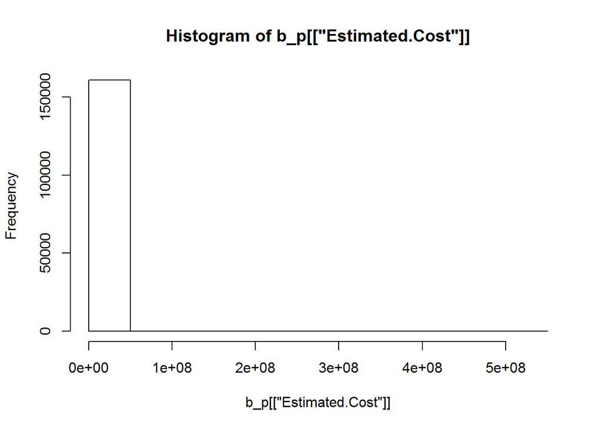

```r
hist(b_p[["Estimated.Cost"]])
```

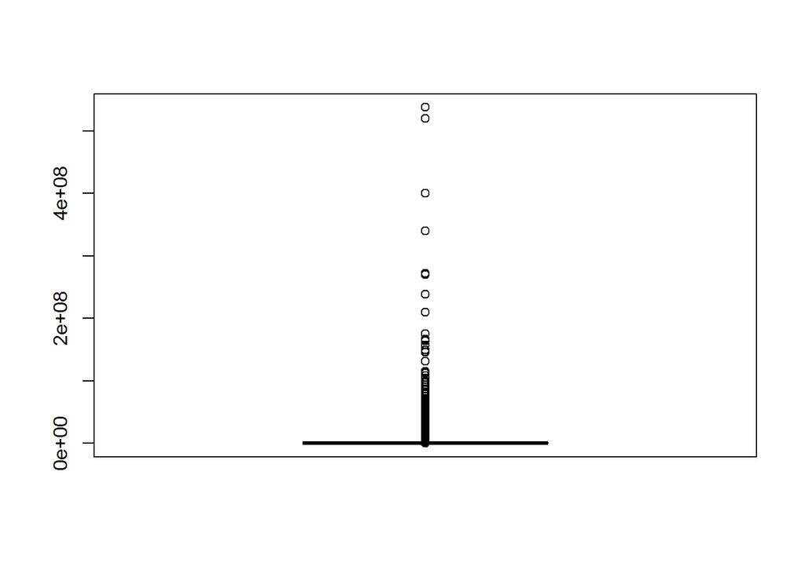

```r
boxplot(b_p[["Estimated.Cost"]])
```

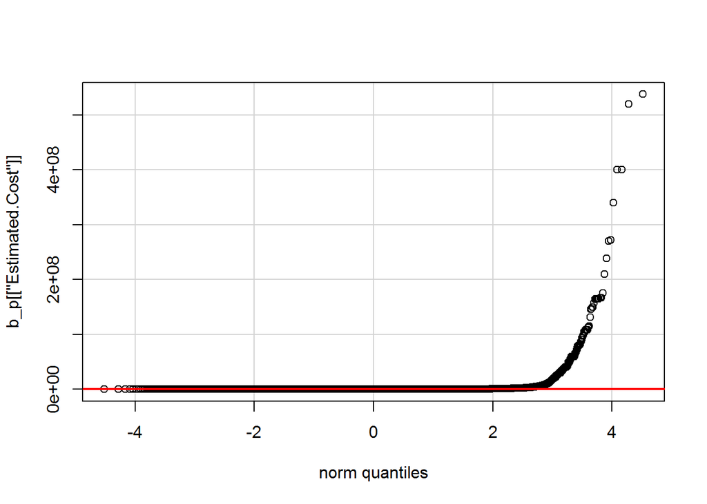

```r
qqPlot(b_p[["Estimated.Cost"]])
```

According to the summary and hist gram above, it’s highly possible that some too big and too small values are incorrect. So I decide to cut them off.

```r
b_p_estimated_cost_new<-dplyr::filter(b_p,Estimated.Cost<4e+05 & Estimated.Cost>100)
summary(b_p_estimated_cost_new[["Estimated.Cost"]])
```

```
##    Min. 1st Qu.  Median    Mean 3rd Qu.    Max.
##     102    5000   13500   34222   35000  399069
```

```r
plyr::count(is.na(b_p_estimated_cost_new[["Estimated.Cost"]])) #getting the number of data points after cutting possibly incorrect values.
```

| x | freq |
| --- | --- |
| FALSE | 137320 |

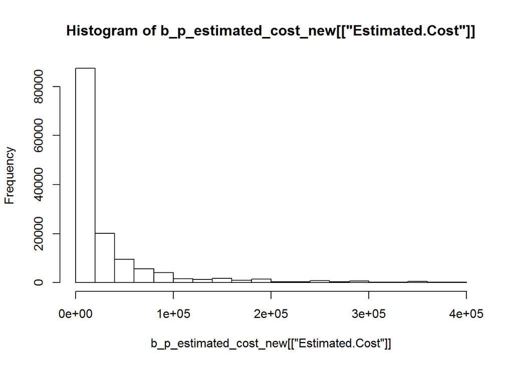

```r
hist(b_p_estimated_cost_new[["Estimated.Cost"]])
```

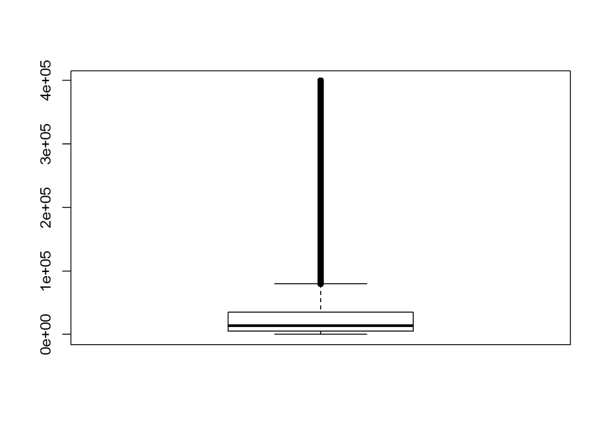

```r
boxplot(b_p_estimated_cost_new[["Estimated.Cost"]])
```

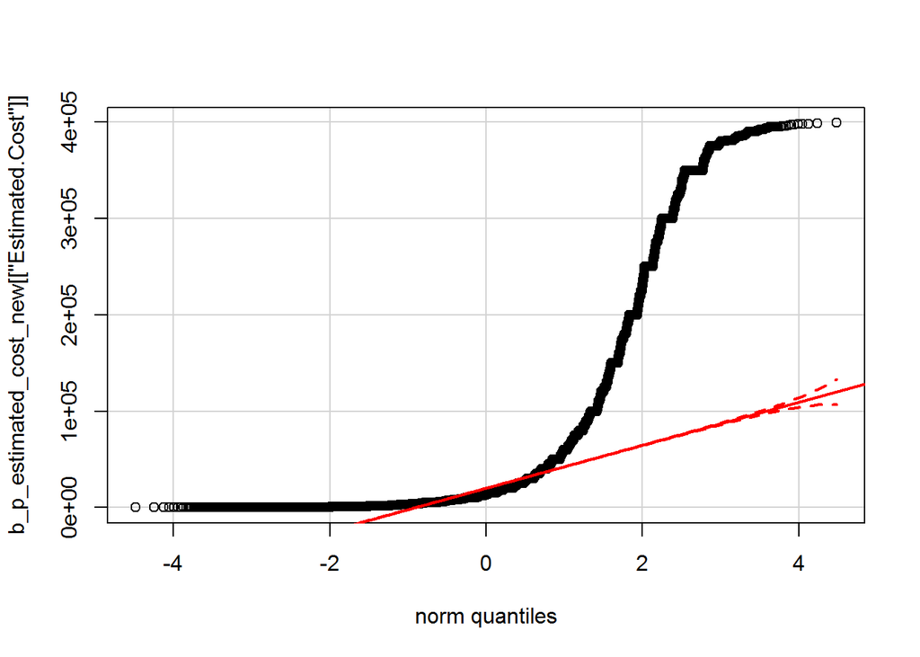

```r
qqPlot(b_p_estimated_cost_new[["Estimated.Cost"]])
```

Visualize Revised,Cost.

```r
summary(b_p[["Revised.Cost"]])
```

```
##      Min.   1st Qu.    Median      Mean   3rd Qu.      Max.      NA's
##         0         1      7000    132856     28708 780500000      6066
```

```r
plyr::count(is.na(b_p[["Revised.Cost"]])) #getting the number of data points except NA points.
```

| x | freq |
| --- | --- |
| FALSE | 192834 |
| TRUE | 6066 |

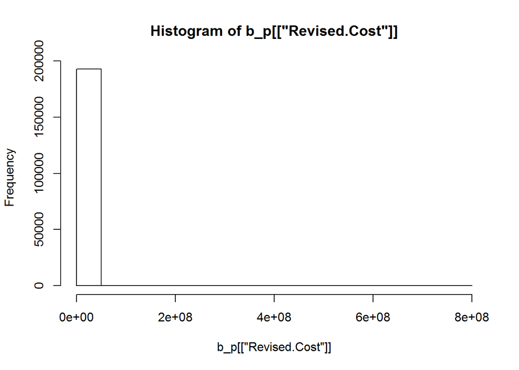

```r
hist(b_p[["Revised.Cost"]])
```

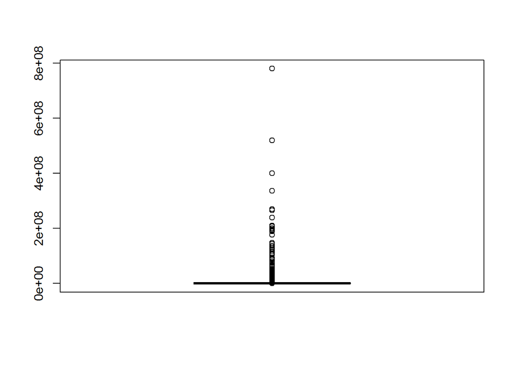

```r
boxplot(b_p[["Revised.Cost"]])
```

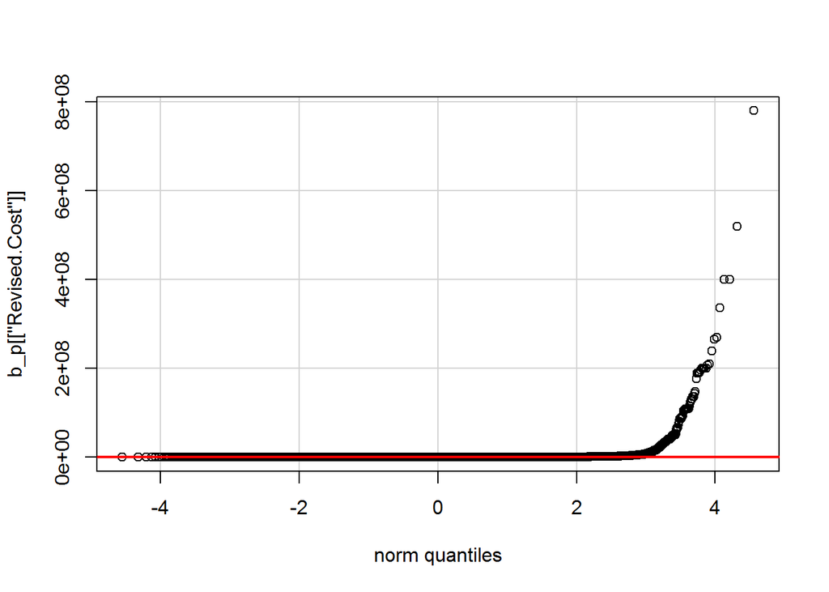

```r
qqPlot(b_p[["Revised.Cost"]])
```

According to the summary and hist gram above, it’s highly possible that some too big and too small values are incorrect. So I decide to cut them off.

```r
b_p_revised_cost_new<-dplyr::filter(b_p,Revised.Cost>100 & Revised.Cost<4e+05)
summary(b_p_revised_cost_new[["Revised.Cost"]])
```

```
##    Min. 1st Qu.  Median    Mean 3rd Qu.    Max.
##     102    5000   15000   36457   40000  399062
```

```r
plyr::count(is.na(b_p_revised_cost_new[["Revised.Cost"]]))  #getting the number of data points after cutting possibly incorrect values.
```

| x | freq |
| --- | --- |
| FALSE | 130389 |

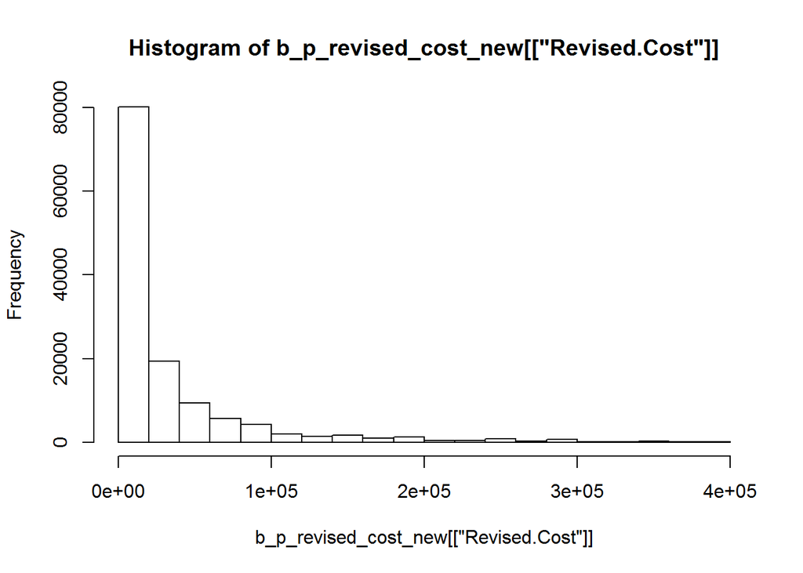

```r
hist(b_p_revised_cost_new[["Revised.Cost"]])
```

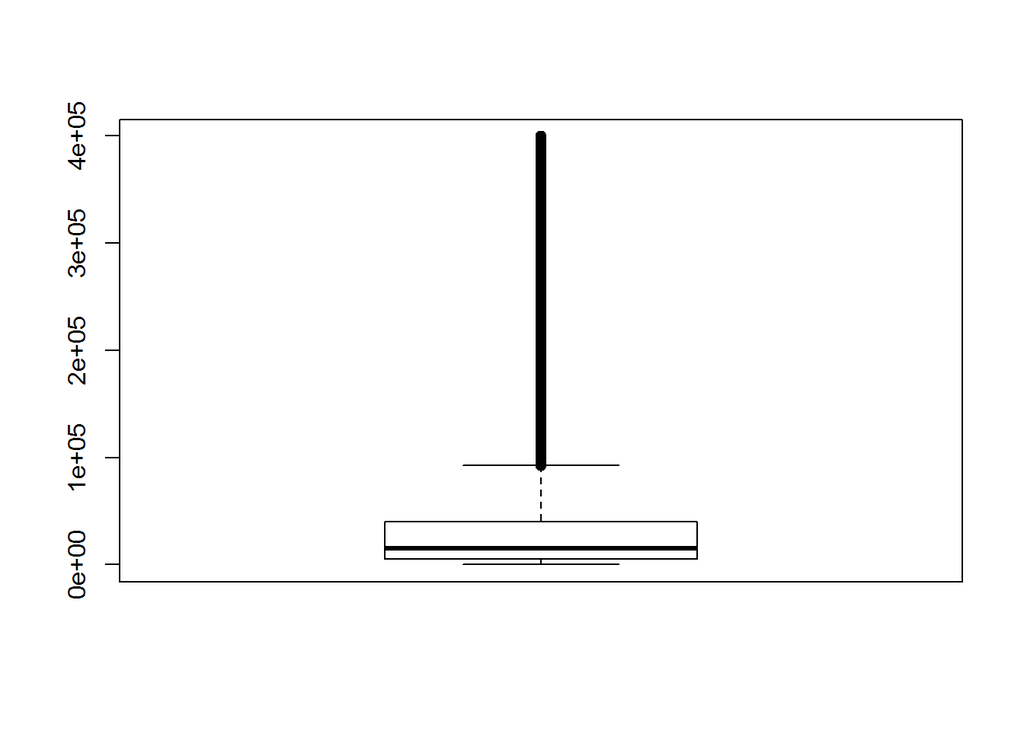

```r
boxplot(b_p_revised_cost_new[["Revised.Cost"]])
```

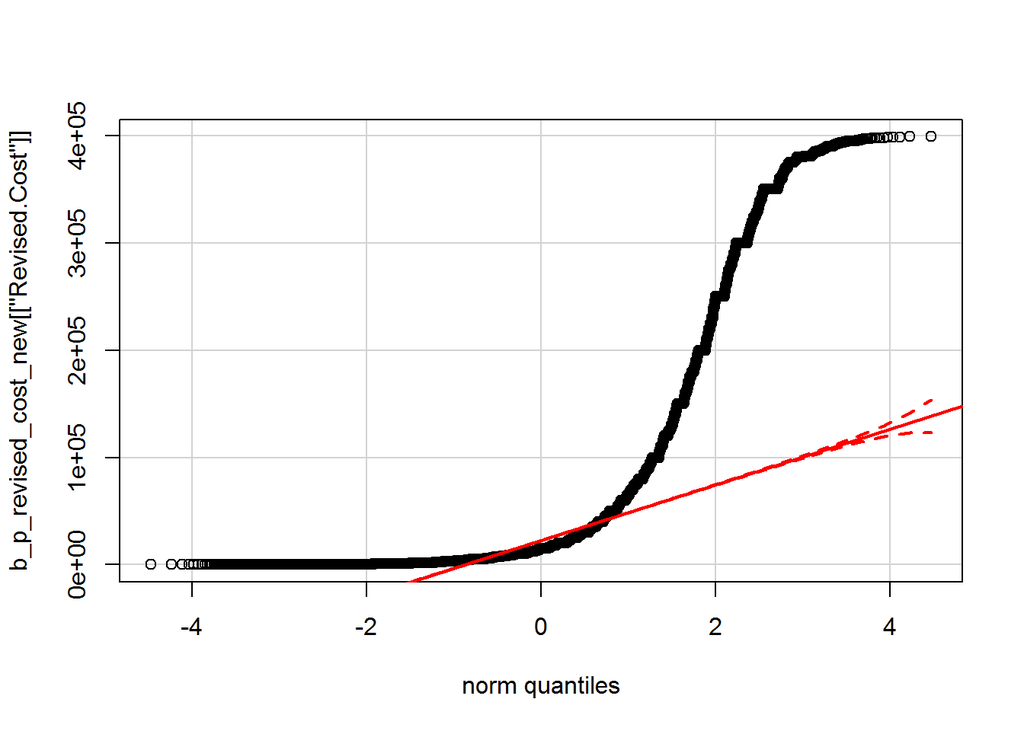

```r
qqPlot(b_p_revised_cost_new[["Revised.Cost"]])
```

Use the Revised.Cost to cover Existing.Cost, fill NAs in Revised.Cost with its Estimated. In this way I come up with a list named “b_p_cost” and visualize it.

```r
b_p_cost<-b_p[["Revised.Cost"]]
b_p_cost[which(is.na(b_p_cost))]<-b_p[["Estimated.Cost"]][which(is.na(b_p_cost))]
summary(b_p_cost)
```

```
##      Min.   1st Qu.    Median      Mean   3rd Qu.      Max.      NA's
##         0         1      7500    152928     30000 780500000       605
```

```r
plyr::count(is.na(b_p_cost))
```

| x | freq |
| --- | --- |
| FALSE | 198295 |
| TRUE | 605 |

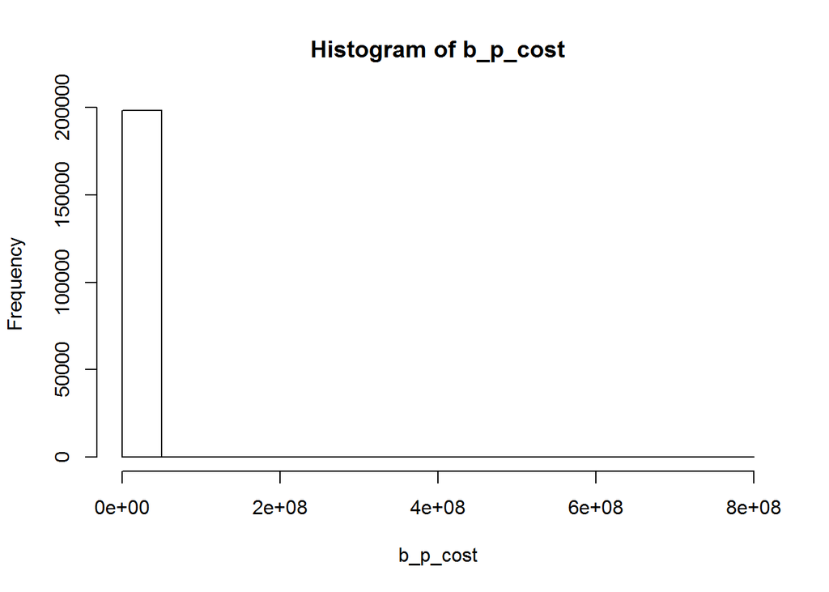

```r
hist(b_p_cost)
```

```r
boxplot(b_p_cost)
```

[output not shown]

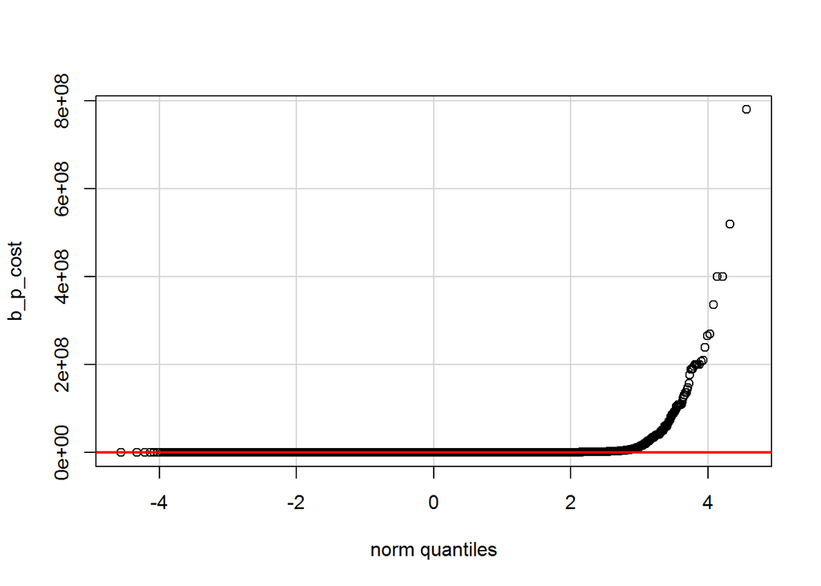

```r
qqPlot(b_p_cost)
```

Using the same method cutting possible incorrect values and visualize it again.

```r
b_p_cost_new<-b_p_cost[which(b_p_cost>100 & b_p_cost<4e+05)]
summary(b_p_cost_new)
```

```
##    Min. 1st Qu.  Median    Mean 3rd Qu.    Max.
##     102    5000   15000   37611   40000  399062
```

```r
plyr::count(is.na(b_p_cost_new))  #getting the number of data points after cutting possibly incorrect values.
```

| x | freq |
| --- | --- |
| FALSE | 134739 |

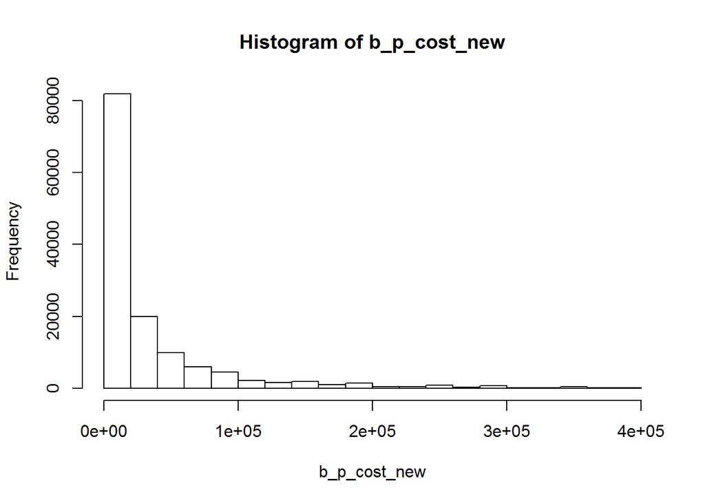

```r
hist(b_p_cost_new)
```

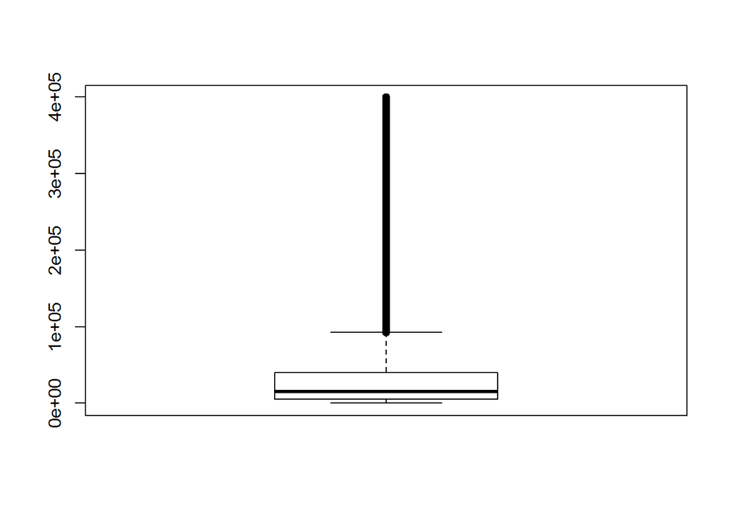

```r
boxplot(b_p_cost_new)
```

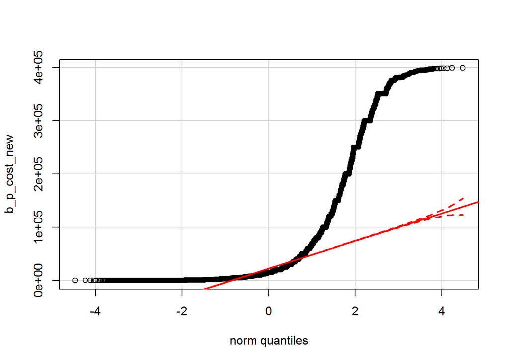

```r
qqPlot(b_p_cost_new)
```

Visualize Existing.Units

```r
summary(b_p[["Existing.Units"]])
```

```
##    Min. 1st Qu.  Median    Mean 3rd Qu.    Max.    NA's
##    0.00    1.00    1.00   15.67    4.00 1907.00   51538
```

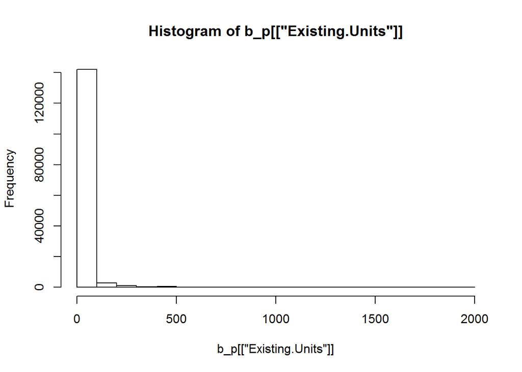

```r
hist(b_p[["Existing.Units"]])
```

```r
boxplot(b_p[["Existing.Units"]])
```

[output not shown]

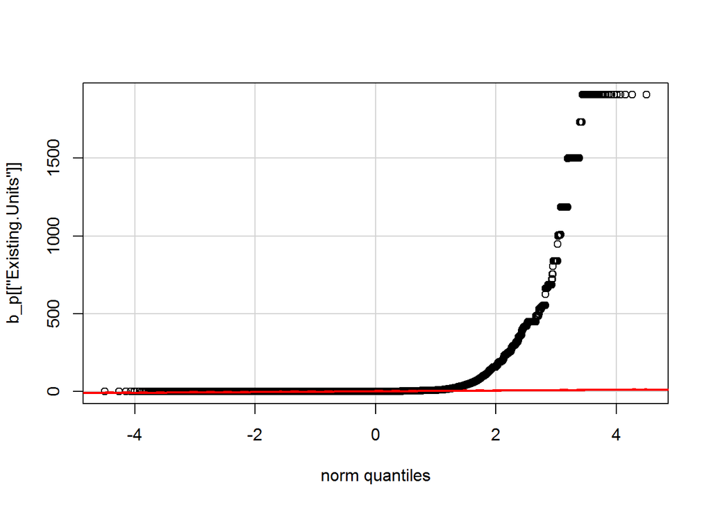

```r
qqPlot(b_p[["Existing.Units"]])
```

Visualize Proposed.Units.

```r
summary(b_p[["Proposed.Units"]])
```

```
##    Min. 1st Qu.  Median    Mean 3rd Qu.    Max.    NA's
##    0.00    1.00    2.00   16.51    4.00 1911.00   50911
```

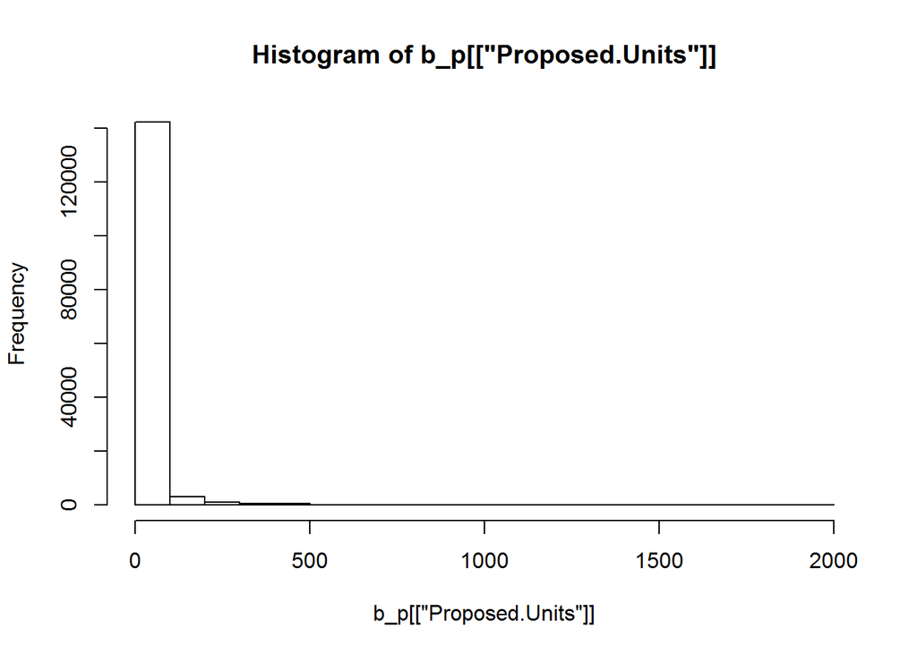

```r
hist(b_p[["Proposed.Units"]])
```

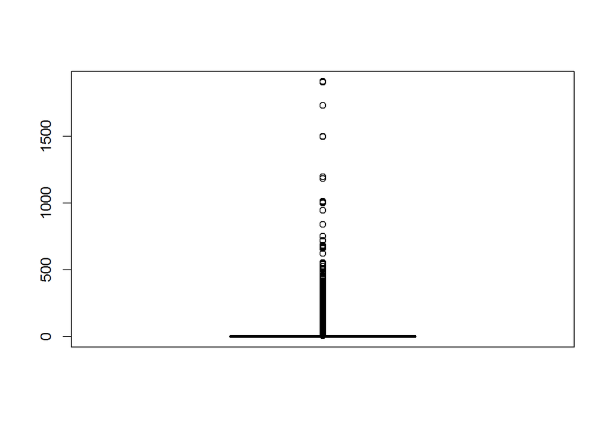

```r
boxplot(b_p[["Proposed.Units"]])
```

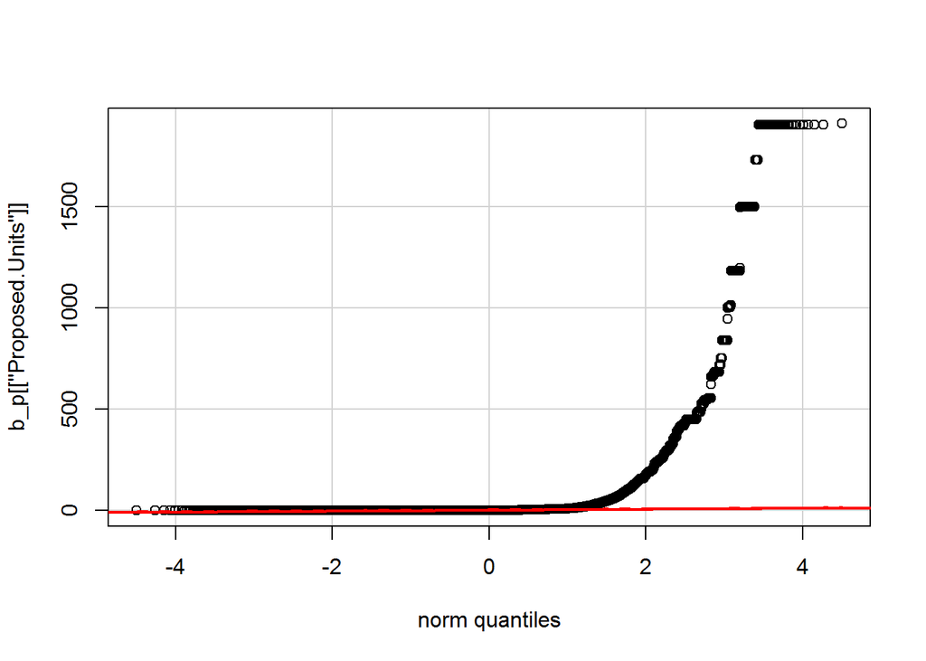

```r
qqPlot(b_p[["Proposed.Units"]])
```

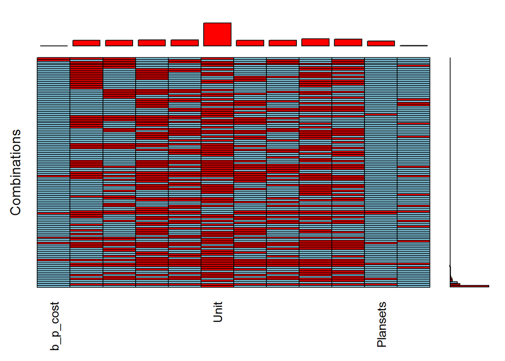

```r
library(VIM)
library(lattice)
library(mice)
b_p_new<-cbind(b_p[["Permit.Number"]],b_p_nominal,b_p_numeric)
#md.pattern(b_p_new)
b_p_missing_visualize=dplyr::select(b_p,Existing.Use,Proposed.Use,Existing.Construction.Type,Proposed.Construction.Type,Unit,Number.of.Existing.Stories,Number.of.Proposed.Stories,Existing.Units,Proposed.Units,Plansets,Supervisor.District)
b_p_missing_visualize<-cbind(b_p_cost,b_p_missing_visualize)
b_p_missing_visualize[["Existing.Use"]][which( b_p_missing_visualize[["Existing.Use"]]=="")]<-NA
b_p_missing_visualize[["Proposed.Use"]][which( b_p_missing_visualize[["Proposed.Use"]]=="")]<-NA
#b_p_missing_visualize[["Revised.Cost"]][which( b_p_missing_visualize[["Revised.Cost"]]<50)]<-NA
aggr(b_p_missing_visualize, prop = TRUE, number = TRUE, combined = TRUE)
```

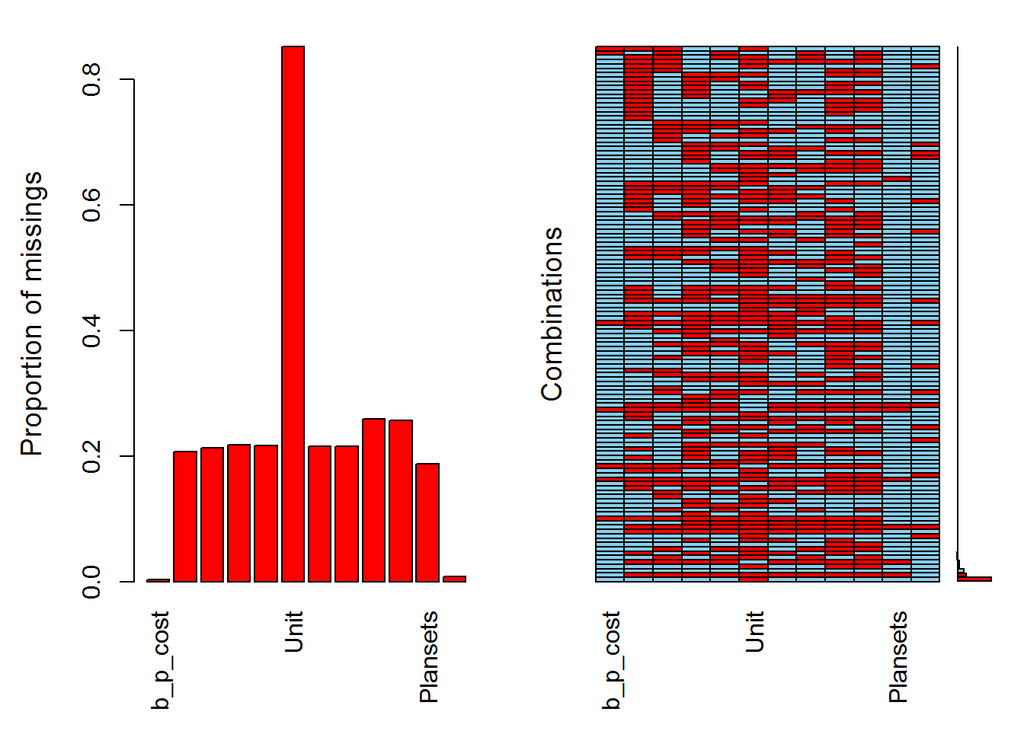

```r
aggr(b_p_missing_visualize, prop = TRUE, number = TRUE, combined = FALSE)
```

There are several theories for NA values.

Most NA values stands for things that never truly exist. For example, as for the Permit.Type “new construction”, the attribute Existing.Unit makes no sense. So NA is introduced to deal with this kind of situation.

Besides, equipment malfunction, data error or refusing of the person interviewed to provide data, things that that can also cause NA in original data set.